# high transcript biases

```
## Loading GOcategoryStats
```

```
## [[1]]
## <environment: namespace:GOcategoryStats>
```

Generate lists of mouse genes by number of transcripts.

### Pre-processing of data on cluster

See closest_gene.Rmd - the generation of the genfo file was the same. We can use the genfo file created from that processing to generate the biased gene lists.

It can also be imported in to the R session so that we can plot the distribution of the number of transcripts per gene in the Mus_musculus.GRCm38.94 genome.

### Number of transcripts per gene in Mus_musculus.GRCm38.94

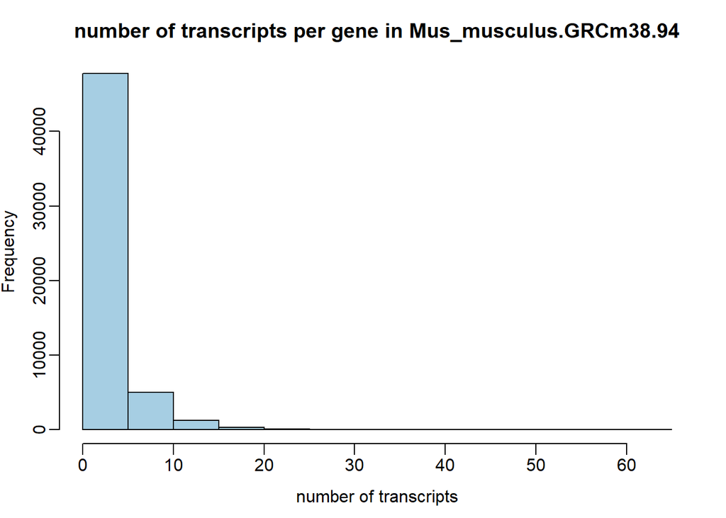

As expected, most genes have very low numbers of transcripts, so we don’t get much information from this plot. We can look at the information in a table format to get actual numbers.

```
##
##     1     2     3     4     5     6     7     8     9    10    11    12
## 34054  5813  3405  2517  1980  1548  1217   946   711   574   387   314
##    13    14    15    16    17    18    19    20    21    22    23    24
##   239   180   124    92    67    67    37    39    25    14    15    10
##    25    26    27    28    29    30    31    32    33    34    35    36
##    17    11     6     7     1     4     7     1     1     3     2     2
##    37    38    39    41    46    47    48    58    62
##     1     1     1     1     1     1     1     1     1
```

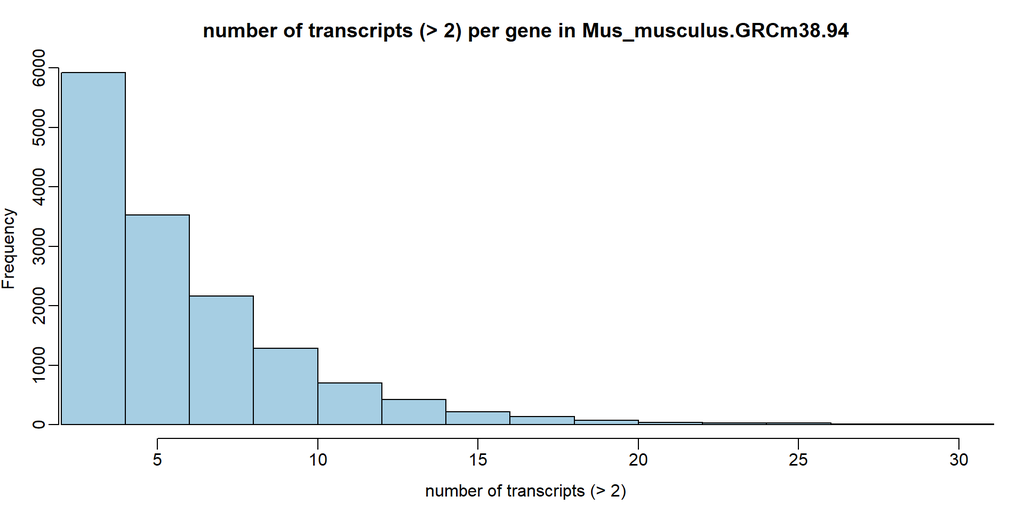

```
## [1] 2255
```

```
## [1] 561
```

```
## [1] 174
```

As there are only 174 genes with more that 20 transcripts, I won’t include this category as the gene lists I’m using contain 200 genes. When I did test a min20 category, almost all the categories came up in the min15 set too.

### Generating the biased gene lists within R

Check they all look right

|  | gene_id | gene_name | chromosome | start | end | strand | biotype | biotype_family | length | GC_content | no_of_transcripts |
| --- | --- | --- | --- | --- | --- | --- | --- | --- | --- | --- | --- |
| 20308 | ENSMUSG00000063884 | Ptcd3 | 6 | 71880638 | 71908750 | - | protein_coding | NA | 28112 | 0.405 | 11 |
| 7342 | ENSMUSG00000031142 | Cacna1f | X | 7607083 | 7635196 | + | protein_coding | NA | 28113 | 0.483 | 11 |
| 19041 | ENSMUSG00000007655 | Cav1 | 6 | 17306335 | 17341452 | + | protein_coding | NA | 35117 | 0.421 | 10 |
| 16420 | ENSMUSG00000039753 | Fbxl5 | 5 | 43744615 | 43821638 | - | protein_coding | NA | 77023 | 0.407 | 12 |
| 53579 | ENSMUSG00000010110 | Stx5a | 19 | 8741413 | 8756069 | + | protein_coding | NA | 14656 | 0.443 | 19 |
| 10787 | ENSMUSG00000034544 | Rsrc1 | 3 | 66981390 | 67358396 | + | protein_coding | NA | 377006 | 0.379 | 10 |

|  | gene_id | gene_name | chromosome | start | end | strand | biotype | biotype_family | length | GC_content | no_of_transcripts |
| --- | --- | --- | --- | --- | --- | --- | --- | --- | --- | --- | --- |
| 14887 | ENSMUSG00000037692 | Ahdc1 | 4 | 133011260 | 133078110 | + | protein_coding | NA | 66850 | 0.548 | 11 |
| 1502 | ENSMUSG00000048000 | Gigyf2 | 1 | 87326998 | 87450796 | + | protein_coding | NA | 123798 | 0.394 | 23 |
| 28173 | ENSMUSG00000055862 | Izumo4 | 10 | 80702184 | 80705373 | + | protein_coding | NA | 3189 | 0.573 | 13 |
| 43838 | ENSMUSG00000034761 | Map4k5 | 12 | 69803750 | 69893200 | - | protein_coding | NA | 89450 | 0.419 | 10 |
| 38021 | ENSMUSG00000020385 | Clk4 | 11 | 51261730 | 51281766 | + | protein_coding | NA | 20036 | 0.405 | 14 |
| 927 | ENSMUSG00000026020 | Nop58 | 1 | 59684971 | 59719044 | + | protein_coding | NA | 34073 | 0.384 | 15 |

|  | gene_id | gene_name | chromosome | start | end | strand | biotype | biotype_family | length | GC_content | no_of_transcripts |
| --- | --- | --- | --- | --- | --- | --- | --- | --- | --- | --- | --- |
| 52409 | ENSMUSG00000063889 | Crem | 18 | 3266048 | 3337748 | - | protein_coding | NA | 71700 | 0.386 | 39 |
| 50385 | ENSMUSG00000042625 | Safb2 | 17 | 56560965 | 56584585 | - | protein_coding | NA | 23620 | 0.512 | 17 |
| 4866 | ENSMUSG00000100303 | 2600014E21Rik | 2 | 75138843 | 75317820 | + | lincRNA | NA | 178977 | 0.418 | 15 |
| 5901 | ENSMUSG00000033526 | Ppip5k1 | 2 | 121310561 | 121355396 | - | protein_coding | NA | 44835 | 0.461 | 18 |
| 20863 | ENSMUSG00000030067 | Foxp1 | 6 | 98925338 | 99522721 | - | protein_coding | NA | 597383 | 0.444 | 31 |
| 45760 | ENSMUSG00000022307 | Oxr1 | 15 | 41447482 | 41861048 | + | protein_coding | NA | 413566 | 0.391 | 16 |

|  | gene_id | gene_name | chromosome | start | end | strand | biotype | biotype_family | length | GC_content | no_of_transcripts |
| --- | --- | --- | --- | --- | --- | --- | --- | --- | --- | --- | --- |
| 24254 | ENSMUSG00000025326 | Ube3a | 7 | 59228750 | 59311536 | + | protein_coding | NA | 82786 | 0.339 | 18 |
| 46230 | ENSMUSG00000022550 | Adck5 | 15 | 76576358 | 76595816 | + | protein_coding | NA | 19458 | 0.504 | 15 |
| 24800 | ENSMUSG00000039176 | Polg | 7 | 79446231 | 79466362 | - | protein_coding | NA | 20131 | 0.506 | 18 |
| 16795.1 | ENSMUSG00000037736 | Limch1 | 5 | 66745827 | 67057158 | + | protein_coding | NA | 311331 | 0.440 | 18 |
| 21787 | ENSMUSG00000030225 | Dera | 6 | 137754546 | 137857340 | + | protein_coding | NA | 102794 | 0.447 | 15 |
| 53101 | ENSMUSG00000042439 | Zfp532 | 18 | 65580230 | 65689443 | + | protein_coding | NA | 109213 | 0.470 | 16 |

### GO overrepresentation analysis

Run the gene lists through a GO overrepresentation analysis.

We don’t want to run the analysis each time the document is knitted as it takes too long. The code was run once and the data saved as an .rda object that can be quickly loaded in to the R session.

See how many significant categories were returned.

```
## [1] "transcript_results"
```

The number of gene sets that returned significant results from the GO overrepresentation analysis

```
## min10 min15
##   100   100
```

The bean plots show the number of categories returned from each gene list. The null results have been removed.

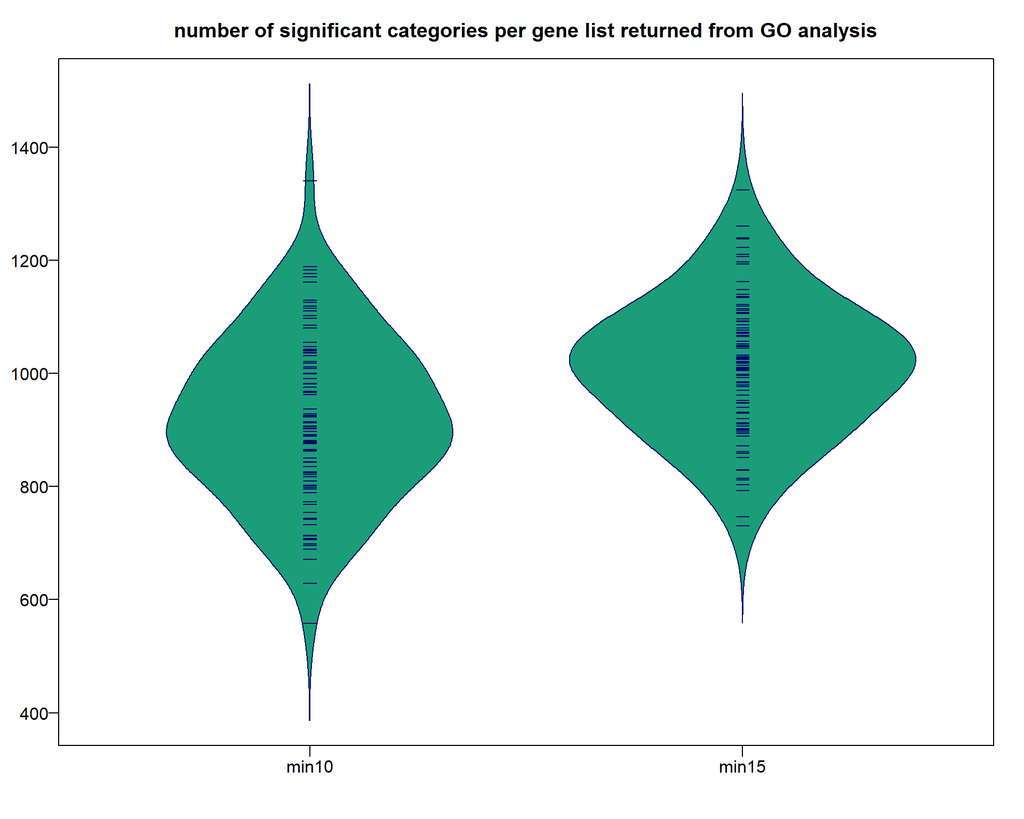

Plot out the p and q values.

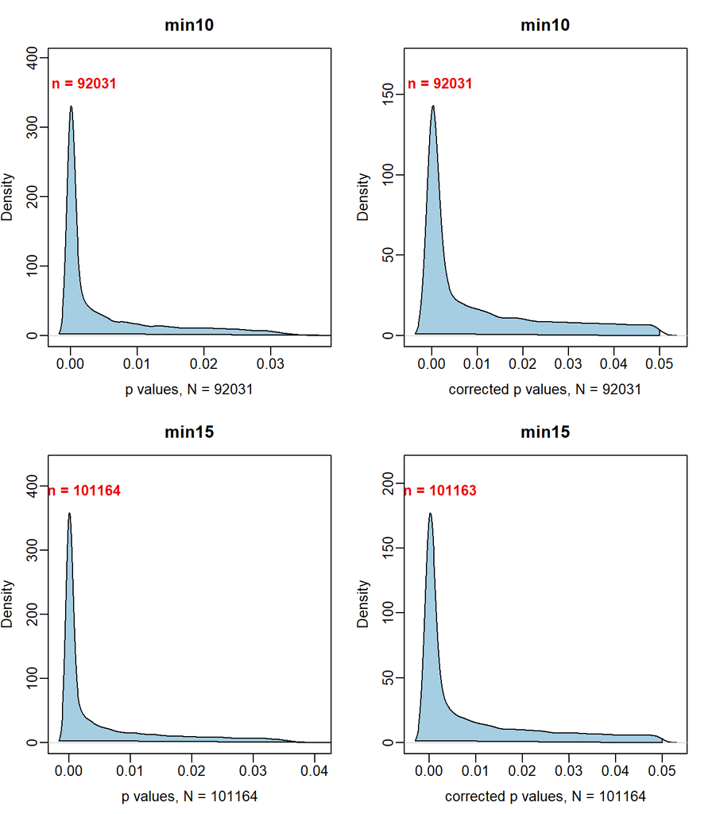

Plot how many times a category appeared.

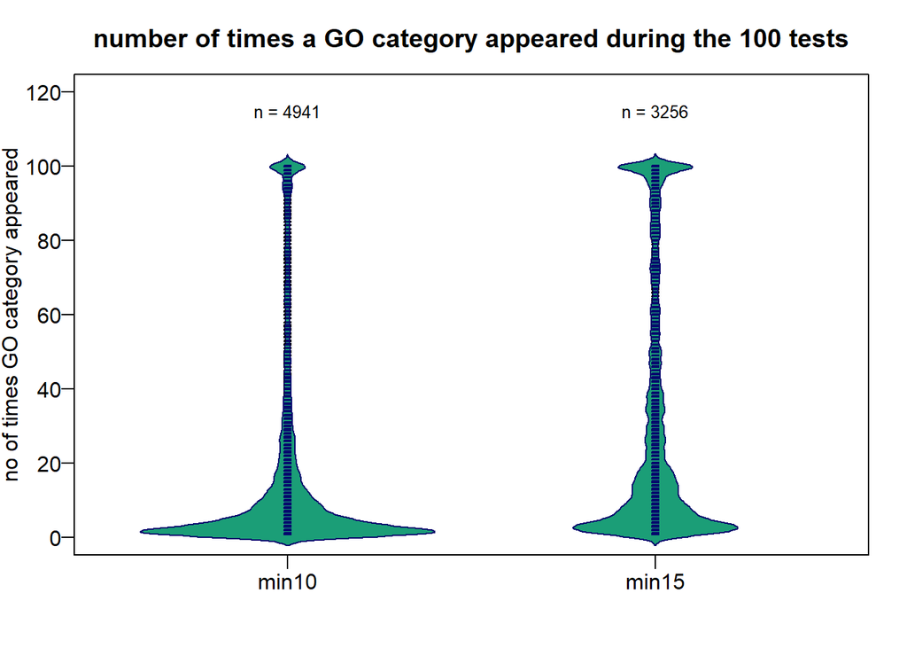

Replot just showing the data for categories that appeared >= 10 times

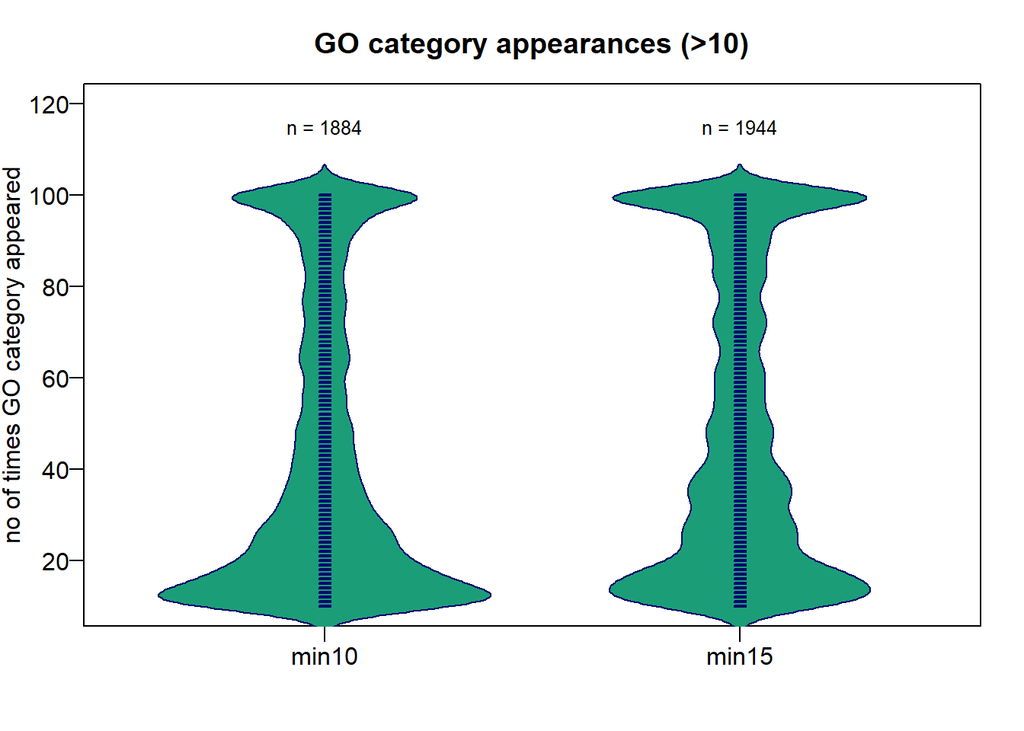

Now we could do with some stats to pick a cutoff for the number of times a category appears. Let’s just select an arbitrary value for now….

The top suspects from min 20 are all in min15 so I’ll leave min20 for now.

Create a dataset that contains these suspect set of categories

Deduplicate

```
## [1] 1448
```

```
## [1] 1448
```

There are 1448 overlapping categories between min15 and min10 so I’ll remove them from the min15 category.

```
## min10 min15
##  1884   496
```